# Housing Dataset

This notebook will examine some characterisitics of the "housing-header.txt" dataset, a dataset of housing data in Boston neighborhoods. For reference:

1. CRIM: per capita crime rate by town
2. ZN: proportion of residential land zoned for lots over 25,000 sq.ft .
3. INDUS: proportion of non retail business acres per town
4. CHAS: Charles River dummy variable (= 1 if tract bounds river; 0 otherwise)
5. NOX: nitric oxides concentration (parts per 10 million)
6. RM: average number of rooms per dwelling
7. AGE: proportion of owner occupied units built prior to 1940
8. DIS: weighted distances to five Boston employment centers
9. RAD: index of accessibility to radial highways
10. TAX: full value property tax rate per 10,000
11. PTRATIO: pupil teacher ratio by town
12. B: 1000(Bk 0.63)^2 where Bk is the proportion of blacks by town
13. LSTAT: percent lower status of the population
14. MEDV: Median value of owner occupied homes in 1000's

First we must load the dataset:

```r
housing<-read.table("housing.header.txt", header=TRUE, sep=",")
colnames(housing)<-c("Crim", "Zn", "Indus", "Chas", "Nox", "Rm", "Age", "Dis", "Rad", "Tax", "Ptratio", "B", "Lstat", "Medv")
head(housing)
```

| Crim | Zn | Indus | Chas | Nox | Rm | Age | Dis | Rad | Tax | Ptratio | B | Lstat | Medv |
| --- | --- | --- | --- | --- | --- | --- | --- | --- | --- | --- | --- | --- | --- |
| 0.00632 | 18 | 2.31 | 0 | 0.538 | 6.575 | 65.2 | 4.0900 | 1 | 296 | 15.3 | 396.90 | 4.98 | 24.0 |
| 0.02731 | 0 | 7.07 | 0 | 0.469 | 6.421 | 78.9 | 4.9671 | 2 | 242 | 17.8 | 396.90 | 9.14 | 21.6 |
| 0.02729 | 0 | 7.07 | 0 | 0.469 | 7.185 | 61.1 | 4.9671 | 2 | 242 | 17.8 | 392.83 | 4.03 | 34.7 |
| 0.03237 | 0 | 2.18 | 0 | 0.458 | 6.998 | 45.8 | 6.0622 | 3 | 222 | 18.7 | 394.63 | 2.94 | 33.4 |
| 0.06905 | 0 | 2.18 | 0 | 0.458 | 7.147 | 54.2 | 6.0622 | 3 | 222 | 18.7 | 396.90 | 5.33 | 36.2 |
| 0.02985 | 0 | 2.18 | 0 | 0.458 | 6.430 | 58.7 | 6.0622 | 3 | 222 | 18.7 | 394.12 | 5.21 | 28.7 |

We then plot all samples with respect to the crime rate:

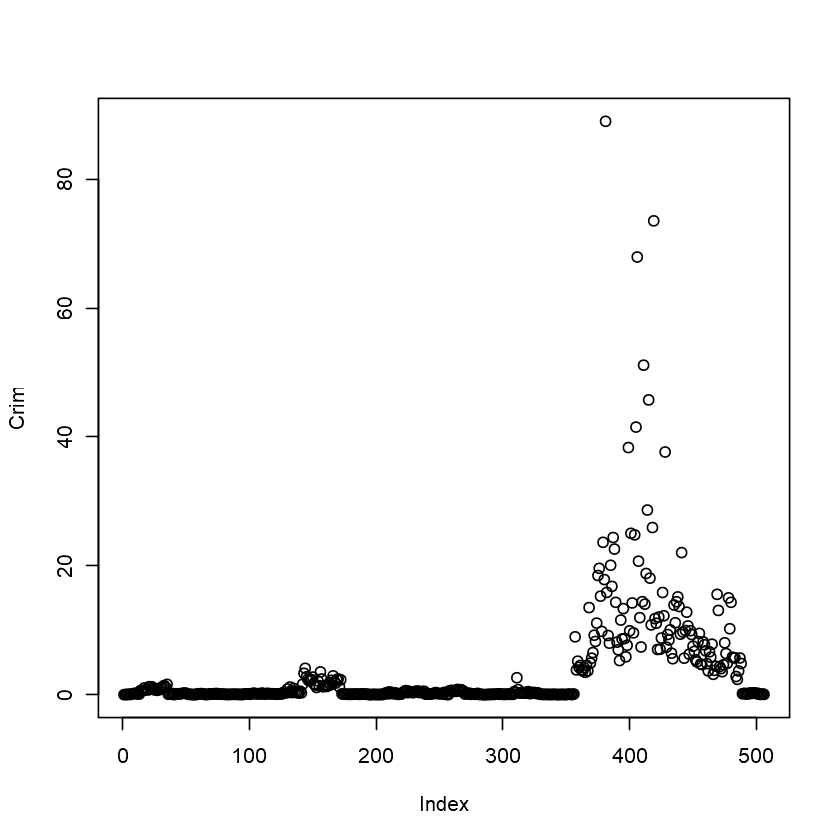

```r
attach(housing)
plot(Crim)
```

We then continue with our example using crime rate: plotting its density as well as a histogram:

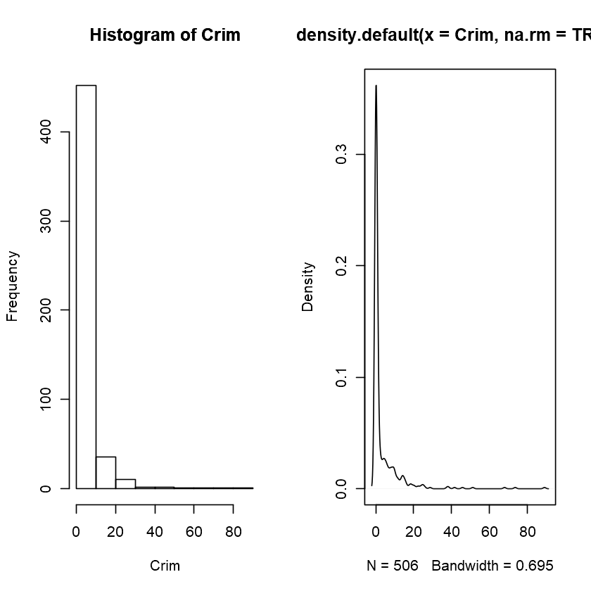

```r
par(mfrow=c(1,2))
hist(Crim)
title ("Histogram of Crim")
plot(density(Crim, na.rm=TRUE))
```

We then plot crime rate, number of rooms, age of the home, and property tax rate with respect to median house value, in order to examine the correlation:

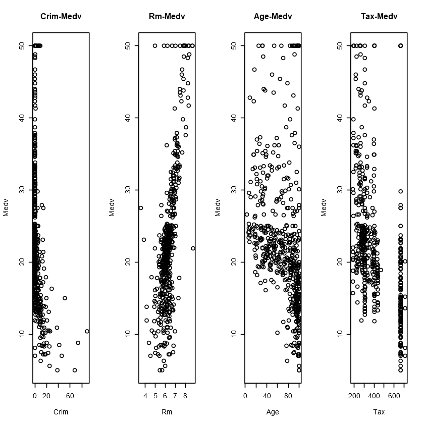

```r
par(mfrow=c(1,4))
plot(Crim, Medv)
title("Crim-Medv")
plot(Rm, Medv)
title("Rm-Medv")
plot(Age, Medv)
title("Age-Medv")
plot(Tax, Medv)
title("Tax-Medv")
```

From the scatterplots, we can observe that:

- Crim and Medv appear to have a negative correlation
- Rm and Medv appear to have a positive correlation
- Age and Medv appear to have a negative correlation
- Tax and Medv appear to have a negative correlation

We can then report the pairwise correlation between every two variables using a level plot:

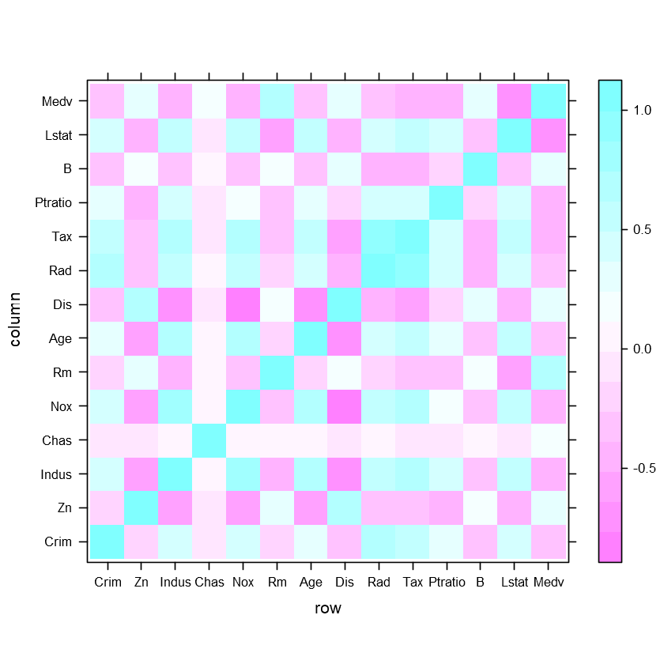

```r
cv<-cor(housing)
library(lattice)
levelplot(cv)
```

Observe the level plot above. The following variables are negatively correlated with Medv:

- Lstat
- Ptratio
- Tax
- Rad
- Age
- Nox
- Indus
- Crim

The following variables have little or no correlation with Medv:

- B
- Dis
- Chas
- Zn

The following variables are positively correlated with Medv:

- Medv itself (correlation of 1 expected)
- Rm

We also demonstrate this same correlation with scatterplots:

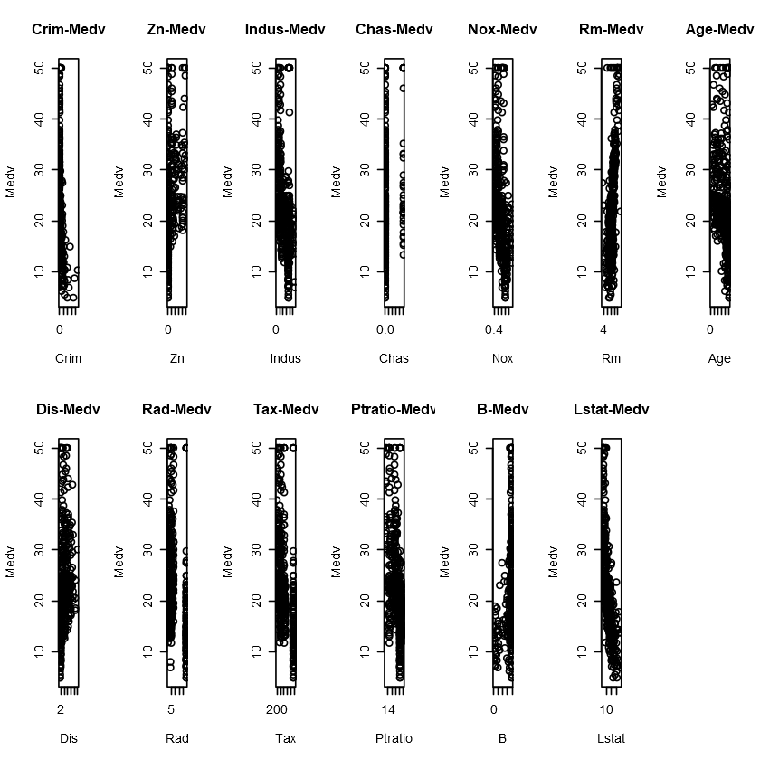

```r
par(mfrow=c(2, 7))
plot(Crim, Medv)
title("Crim-Medv")
plot(Zn, Medv)
title("Zn-Medv")
plot(Indus,Medv)
title("Indus-Medv")
plot(Chas, Medv)
title("Chas-Medv")
plot(Nox,Medv)
title("Nox-Medv")
plot(Rm, Medv)
title("Rm-Medv")
plot(Age, Medv)
title("Age-Medv")
plot(Dis, Medv)
title("Dis-Medv")
plot(Rad, Medv)
title("Rad-Medv")
plot(Tax, Medv)
title("Tax-Medv")
plot(Ptratio, Medv)
title("Ptratio-Medv")
plot(B, Medv)
title("B-Medv")
plot(Lstat, Medv)
title("Lstat-Medv")
```

The attributes that are posiitvely correlated with Medv will have a generally increasing trend on the scatterplot (x increases as y increases). The attributes that are independent of Medv will have no easily observable trend. The attributes that are negatvely correlated with Medv will have a generally decreasing trend on the scatterplot (x decreases as y increases)